# Contagion Model

Andrew Lee

# Background

Contagion models describe the spread of an attribute in a network: diseases in contact networks, behaviors in friend networks, ideas in discussion networks, and so on. Data in this project is from a study on how doctors adopted a new drug. Coleman, Katz, and Menzel collected data on doctors in several cities in Illinois, including the first date on which they prescribed tetracycline (a new drug at the time) and which other doctors they went to for advice or discussion of treatment options. One of the theories investigated in the paper was that doctors who knew other doctors who had already prescribed the drug adopted it more quickly than those who didn’t. This behavior can be described as a contagion model.

In this project, I will simulate from a contagion model and use the simulations to obtain an approximate posterior distribution of the contagion parameter using approximate Bayesian computation. The contagion model I will use is the susceptible-infected (SI) contagion model. In this model, each of the nodes in a network can be either susceptible to infection or already infected. At each time step, each infected node picks one of its neighbors uniformly at random. If the chosen neighbor is not infected, it becomes infected with probability p. For this project, each of the nodes is a doctor, an “infected” node is a doctor who has prescribed tetracycline, and the links in the network are doctors who discuss cases with each other.

*Note: The data on the website is a subset of the data sets available at http://moreno.ss.uci.edu/data.html#ckm. You can find more information about the data attributes there. For this study, we are only using the doctors from Peoria*

Load data:

Load data and packages:

```r
library(ggplot2)
library(qgraph)

network = read.csv("network.csv")
attributes = read.csv("attributes.csv")
```

Identify doctors who initially adopted the new drug:

```r
initialAdopt = attributes[attributes$adoption_date == 1,]
```

An overview of the contagion network is:

```r
dim(network)
```

```
## [1] 117 117
```

```r
network[1:5,1:14]
```

```
##   V2 V3 V4 V5 V6 V7 V8 V9 V10 V11 V12 V13 V14 V15
## 1  0  0  0  0  0  0  0  0   0   0   0   0   0   0
## 2  0  0  0  0  0  0  0  0   0   0   0   0   0   0
## 3  0  0  0  0  0  0  0  0   0   0   0   0   0   0
## 4  0  0  0  0  0  0  1  0   0   0   0   0   0   0
## 5  0  0  0  0  0  0  0  0   0   0   0   1   0   0
```

The network dataset represents network between 117 doctors. If doctor i listed doctor j as someone he discussed patients with, then the [i,j] element in the data is 1, otherwise 0.

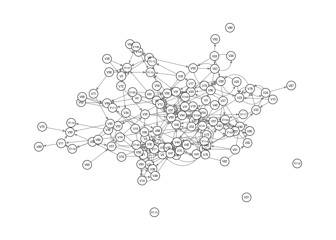

```r
rownames(network) = colnames(network)
qgraph(network)
```

The attributes dataset has more information about the doctors, but the only important column for this study is adoption_date, the month in which the doctor first prescribed the drug.

```r
head(attributes)
```

```
##   city adoption_date med_sch_yr meetings jours free_time discuss clubs
## 1    1             1          2        2     8         1       1     0
## 2    1            12          6        0     4         3       2     0
## 3    1             8          4        1     6         3       1     0
## 4    1             9          5        1     5         1       1     0
## 5    1             9          4        1     3         1       2     0
## 6    1            10          3        0     6         2       2     0
##   friends community patients proximity specialty
## 1       1         6        5         3         3
## 2       4         1        4         3         1
## 3       3         5        4         2         2
## 4       1         4        3         3         1
## 5       2         5        3         2         1
## 6       1         5        5         3         2
```

### Function that simulates from a contagion model:

The function takes the following parameters:

- network
- set of initially infected nodes
- The infection probability p
- The number of time steps to simulate

It returns a vector giving the time point at which each node was infected.

```r
simModel = function(network, initialNodes, adoptProb, stepNumber)
{
  simAttributes = data.frame(doctor = as.integer(rownames(attributes)),
                             adoptTime = NA)

  #set the initial adoptors in the data
  initialNodes = as.integer(rownames(initialAdopt))
  simAttributes[initialNodes,]$adoptTime = 1

  for (i in 2:stepNumber)
  {
    #get the row number of the adopted nodes
    adoptedNodes = rownames(simAttributes[!is.na(simAttributes$adoptTime),])
    adoptedNodes = as.integer(adoptedNodes)

    #loop through the nodes which have adopted
    for (j in adoptedNodes)
    {
      currentDoc = simAttributes[j,]$doctor

      #get the nodes the starting node interacts with
      neighbors = getNeighbors(startingNode = currentDoc,
                                network = network,
                                simAttributes = simAttributes)

      #drop any possible NA values
      neighbors = neighbors[!is.na(neighbors$doctor),]

      if (nrow(neighbors) > 0)
      {
        #select a neighbor
        samples = neighbors$doctor
        neighborIdx = sample(samples, 1)

        neighbor = neighbors[neighbors$doctor == neighborIdx,]

        #check to see if the neighbor has already adopted
        neighborAdoptDate = neighbor$adoptTime

        if (is.na(neighborAdoptDate) ||
            neighborAdoptDate > stepNumber)
        {
          #check to see if the doctor will adopt
          adopted = rbinom(n = 1, size = 1, prob = adoptProb)

          if (adopted == 1)
          {
            simAttributes[simAttributes$doctor == neighbor$doctor,]$adoptTime = i
          }
        }
      }
    }
  }

  return(simAttributes)
}
```

# Bayesian Statistics

Suppose we have data $y_1,\ldots, y_n$ that we believe can be described by a probability model with parameters $\theta$.

We also have a prior distribution on the parameters $\theta$, describing our belief about the values of those parameters before seeing any of the data.

$$\begin{align*} y_i \mid \theta &\sim P(y_i \mid \theta), \quad i = 1,\ldots, n\\ \theta & \sim \pi(\theta) \end{align*}$$

##### For example:

Data $y_i$ are heights of men entering the military

We think that the $y_i$ are distributed $\mathcal N(\theta, \sigma^2)$

We have some prior belief about $\theta$, maybe that it is around 70".

We quantify our prior belief about $\theta$ as $\theta \sim \mathcal N(70, 5)$

Once we have seen the actual heights, we can “update” our belief about $\theta$ by computing the posterior distribution $P(\theta \mid y_1,\ldots, y_n)$

By applying Bayes’ rule, we can compute the posterior distribution of the parameters given the data:
$$\begin{align*} P(\theta \mid y_1,\ldots, y_n) &= \frac{P(y_1,\ldots, y_n \mid \theta)\pi(\theta)}{P(y_1,\ldots, y_n)} \end{align*}$$

We want to know as much about this distribution as possible. For simple cases it is available in closed form, while for more complicated cases our best hope is to draw samples of it. From those samples we can compute posterior means, variances, etc. using the Monte Carlo methods.

**Inputs:**

A target posterior: $P(\theta \mid y_{\text{obs}}) \propto P(y_{\text{obs}} \mid \theta) \pi(\theta)$

A way of simulating from $P(y_{\text{obs}} \mid \theta)$

A prior on the parameters $\pi(\theta)$

**Sampling:** for $i = 1,\ldots, N$:

Generate $\theta^{(i)} \sim \pi(\theta)$

Generate $y^{(i)} \sim p(y \mid \theta^{(i)})$

If $y^{(i)} = y_{\text{obs}}$, accept $\theta^{(i)}$

##### How does this work?

Our draws $(\theta^{(i)}, y^{(i)})$ are samples from the joint distribution $P(\theta, y)$

Keeping only the values for which $y^{(i)} = y_{\text{obs}}$ is the definition of conditioning on $y_{\text{obs}}$.

# ABC: The algorithm

**Inputs:**

A target posterior: $\pi(\theta \mid y_{\text{obs}}) \propto p(y_{\text{obs}} \mid \theta) \pi(\theta)$

A way of simulating from $p(y_{\text{obs}} \mid \theta)$

A prior on the parameters $\pi(\theta)$

A summary statistic function $s$

A tolerance $\epsilon$

**Sampling:** for $i = 1,\ldots, N$:

Generate $\theta^{(i)} \sim g(\theta)$

Generate $y^{(i)} \sim p(y \mid \theta^{(i)})$

If $\|s(y^{(i)}) - s(y_{\text{obs}})\| < \epsilon$, accept $\theta^{(i)}$

This method generates approximate samples from the posterior distribution

### Simulation from the model given the real data:

Simulate from the data provided by Coleman, Katz, and Menzel. The data contains parameters for the network (the doctor discussion network), the initially infected nodes (the doctors who prescribed tetracycline in month1), and the number of time steps (18months). Simulate each for p=.1, .5, .9.

```r
getNeighbors <- function(startingNode, network, simAttributes)
{
  #get the nodes the starting node interacts with
  neighborNet <- network[startingNode,
                         network[startingNode,] == 1]
  neighborCols <- colnames(neighborNet)

  neighborIdx <- as.integer(substring(neighborCols, 2))

  neighbors <- simAttributes[neighborIdx,]

  return(neighbors)
}
```

```r
abcSim <- function(numberSims, epsilon)
{
  observedTimes <- attributes[attributes$adoption_date <= 18,]$adoption_date
  obsMean <- mean(observedTimes)

  probs <- runif(numberSims, min = 0, max = 1)
  meanDiffs <- rep(NA, numberSims)

  acceptNumber <- epsilon * numberSims

  for (i in 1:length(probs))
  {
    prob <- probs[i]

    newData <- simModel(network, initialAdopt, prob, 18)
    adoptTimes <- na.omit(newData$adoptTime)

    meanDiffs[i] <- abs(mean(adoptTimes) - obsMean)
  }

  orderedDiffs <- meanDiffs[order(meanDiffs)]

  acceptedProbs <- probs[c(1:acceptNumber)]

  print(acceptedProbs)
}
```

```r
calcDistance <- function(simData, obsData)
{
  norm <- sqrt(sum(abs(obsData - simData) ^ 2))

  distance <- 0.5 * norm

  return(distance)
}
```

```r
data = simModel(network, initialAdopt, 0.1, 18)
nrow(data[!is.na(data$adoptTime),])
```

```
## [1] 12
```

```r
prob1 = simModel(network, initialAdopt, 0.1, 18)
prob5 = simModel(network, initialAdopt, 0.5, 18)
prob9 = simModel(network, initialAdopt, 0.9, 18)
```

#### Contagion simulation under prior adoption rate = 0.1

```r
head(prob1, 10)
```

```
##    doctor adoptTime
## 1       1         1
## 2       2        15
## 3       3        NA
## 4       4        NA
## 5       5        NA
## 6       6        NA
## 7       7        NA
## 8       8        NA
## 9       9        NA
## 10     10        NA
```

#### Contagion simulation under prior adoption rate = 0.5

```r
head(prob5, 10)
```

```
##    doctor adoptTime
## 1       1         1
## 2       2         2
## 3       3        NA
## 4       4        10
## 5       5        17
## 6       6        13
## 7       7        11
## 8       8        14
## 9       9        NA
## 10     10        NA
```

#### Contagion simulation under prior adoption rate = 0.9

```r
head(prob9, 10)
```

```
##    doctor adoptTime
## 1       1         1
## 2       2        10
## 3       3        NA
## 4       4         8
## 5       5        12
## 6       6         3
## 7       7         8
## 8       8        11
## 9       9        NA
## 10     10        NA
```

```r
observedTimes = attributes[attributes$adoption_date <= 18,]$adoption_date
accepted = abcSim(1000, 0.05)
```

```
##  [1] 0.03356454 0.58436926 0.36447743 0.74943735 0.67550839 0.36256578
##  [7] 0.41564245 0.96566860 0.61636123 0.73560969 0.30001486 0.82316104
## [13] 0.47231084 0.04975128 0.55703389 0.60815508 0.31258560 0.59498926
## [19] 0.19600313 0.47429237 0.32624423 0.92858373 0.95447408 0.53394827
## [25] 0.73330618 0.32918722 0.82612672 0.91723578 0.49350809 0.83843397
## [31] 0.77714790 0.39205567 0.14300596 0.62652397 0.14133746 0.46612849
## [37] 0.72573154 0.98505917 0.59289502 0.97950955 0.97762278 0.59479378
## [43] 0.16605124 0.30308268 0.65678527 0.48068057 0.82630535 0.89239532
## [49] 0.47168241 0.99992250
```

```r
plotData = data.frame(accepted = accepted)
```

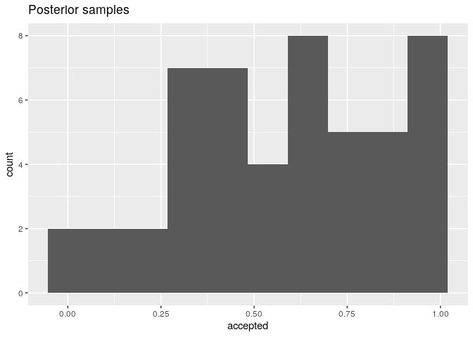

```r
ggplot(data = plotData, aes(x = accepted)) +
  geom_histogram(bins = 10) +
  labs(title = "Posterior samples")
```

```r
summary(plotData$accepted)
```

```
##    Min. 1st Qu.  Median    Mean 3rd Qu.    Max.
## 0.03356 0.37137 0.59384 0.57943 0.81166 0.99992
```

Project files are available below: https://github.com/aleedk1123/SIcontagion